### Problem 1

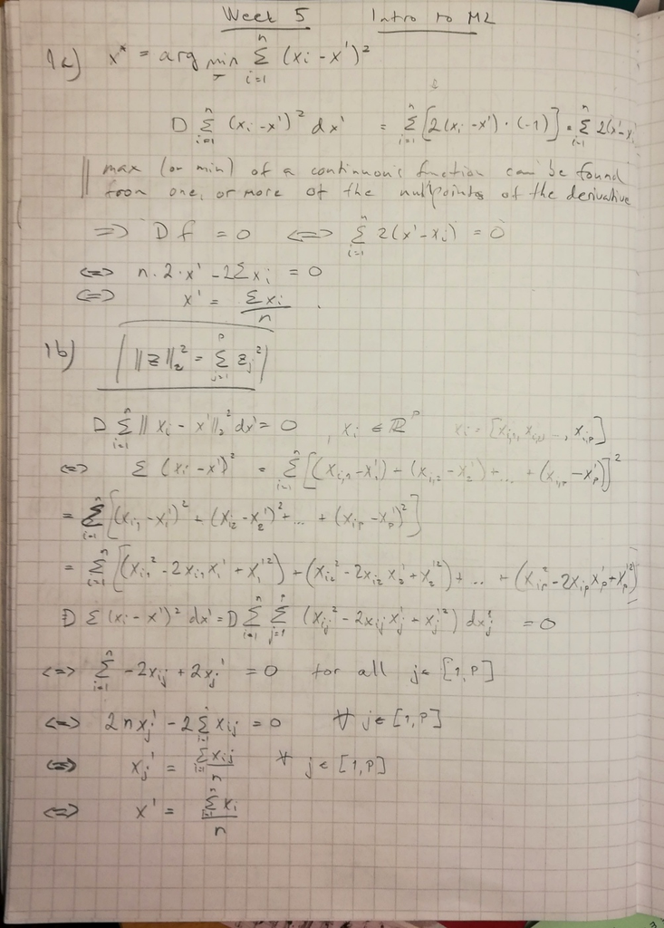

Solutions 1(a) and 1(b)

### Problem 2

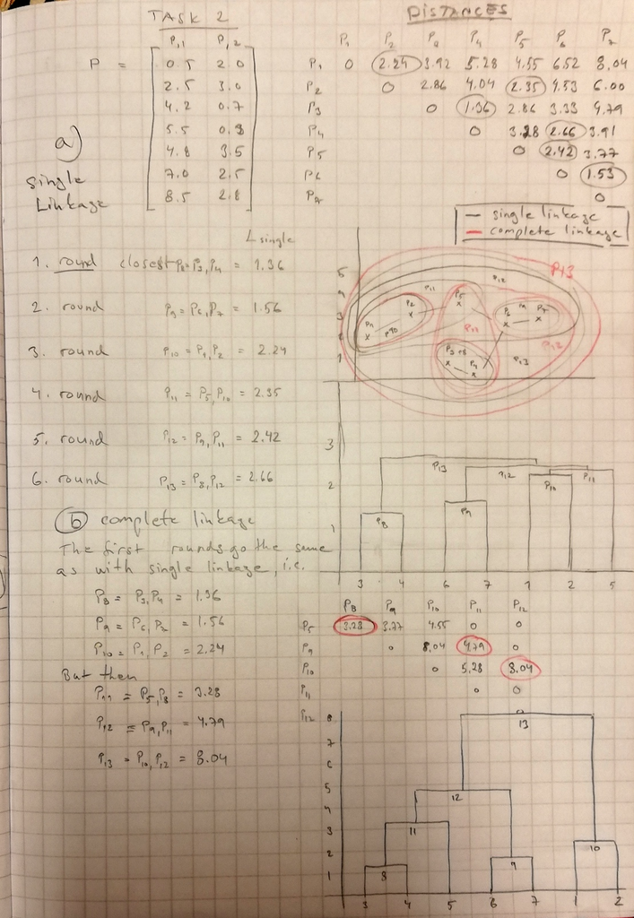

Write your own implementation of the so called Lloyd’s algorithm for K-means. The algorithm is explained in the slides and Algorithm 10.1 in the textbook. This should be a function that takes as inputs the data matrix, and outputs the final cluster means and the assignments specifying which data vectors are assigned to which cluster after convergence of the algorithm. (Use matrix operations wherever possible, avoiding explicit loops, to speed up the algorithm sufficiently for running the algorithm on the MNIST data below.)

#### Algorithm 10.1 K-Means Clustering:

- 1. Randomly assign a number, from 1 to K, to each of the observations. These serve as initial cluster assignments for the observations.
- 2. Iterate until the cluster assignments stop changing:
- 1. For each of the K clusters, compute the cluster centroid. The kth cluster centroid is the vector of the p feature means for the observations in the kth cluster.
- 2. Assign each observation to the cluster whose centroid is closest (where closest is defined using Euclidean distance).

```r
dist <- function(v1,v2)
{
  sqrt(sum((v1-v2)^2))
}
closest <- function(v1,clusters)
{
  mini <- 1
  mind <- dist(v1,clusters[1,])
  if(dim(clusters)[1]>1)
  {
    for(i in 2:dim(clusters)[1])
    {
      d <- dist(v1,clusters[i,])
      if(d < mind)
      {
        mini <- i
        mind <- d
      }
    }
  }
  return (mini)
}
```

```r
Kmeans <- function(obs,K)
{
  #obs is a nxm matrix, with n observations and m features for each observation

  #Randomly assign a number, from 1 to K, to each of the observations.
  #These serve as initial cluster assignments for the observations.

  #clt is a list of clusters, clusters represented as lists
  #each list item is a list of indices of the original list (row indices) of observations
  nobs <- dim(obs)[1]
  nfeat <- dim(obs)[2]
  clt <- sample(x=1:K, size=nobs, replace=TRUE)
  #initialize data structure for centroids
  cent <- matrix(0,nrow = K, ncol = nfeat)
  count <- 0

  #Make sure each cluster has at least one observation
  for (i in 1:K)
  {
    clt[i] = i
  }
  changed = TRUE

  while (changed && (count < 100))
  {
    changed = FALSE
    oldclt <- clt
    #(a) For each of the K clusters, compute the cluster centroid.
    #The kth cluster centroid is the vector of the p feature means
    #for the observations in the kth cluster.
    for (i in 1:K)
    {
      #centroid of this cluster
      rows <- which(clt==i)
      if (length(rows) > 1)
      {
        cent[i,] <- colMeans(obs[rows,], na.rm = FALSE, dims = 1)
      }
      else
      {
        cent[i,] <- obs[rows[1],]
      }
    }

    #(b) Assign each observation to the cluster whose centroid is
    #closest (where closest is defined using Euclidean distance).
    print(paste("Round:",count))

    for (i in 1:nobs)
    {
      clt[i] = closest(obs[i,],cent)
      if(clt[i] != oldclt[i])
      {
        changed <- TRUE
      }
    }

    count <- count + 1
    #print(oldclt)
    #print(clt)

  }
  print(paste("Algorithm converged, total rounds: ", count))
  return (list(cent,clt))
}
```

```r
library(zeallot)
x1 <- rnorm(100,0,1)
x2 <- rnorm(100,0,1)

#cents
#clids
```

```r
data <- cbind(x1, x2)
c(cents,clust) %<-% Kmeans(data,3)
```

```
## [1] "Round: 0"
## [1] "Round: 1"
## [1] "Round: 2"
## [1] "Round: 3"
## [1] "Round: 4"
## [1] "Round: 5"
## [1] "Round: 6"
## [1] "Round: 7"
## [1] "Algorithm converged, total rounds:  8"
```

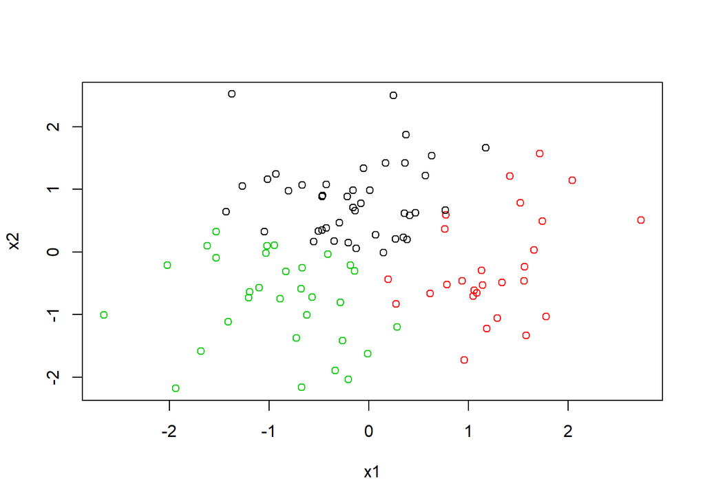

```r
plot(x1,x2,col=clust)
```

```r
c(cents,clust) %<-% Kmeans(data,3)
```

```
## [1] "Round: 0"
## [1] "Round: 1"
## [1] "Round: 2"
## [1] "Round: 3"
## [1] "Round: 4"
## [1] "Round: 5"
## [1] "Round: 6"
## [1] "Round: 7"
## [1] "Algorithm converged, total rounds:  8"
```

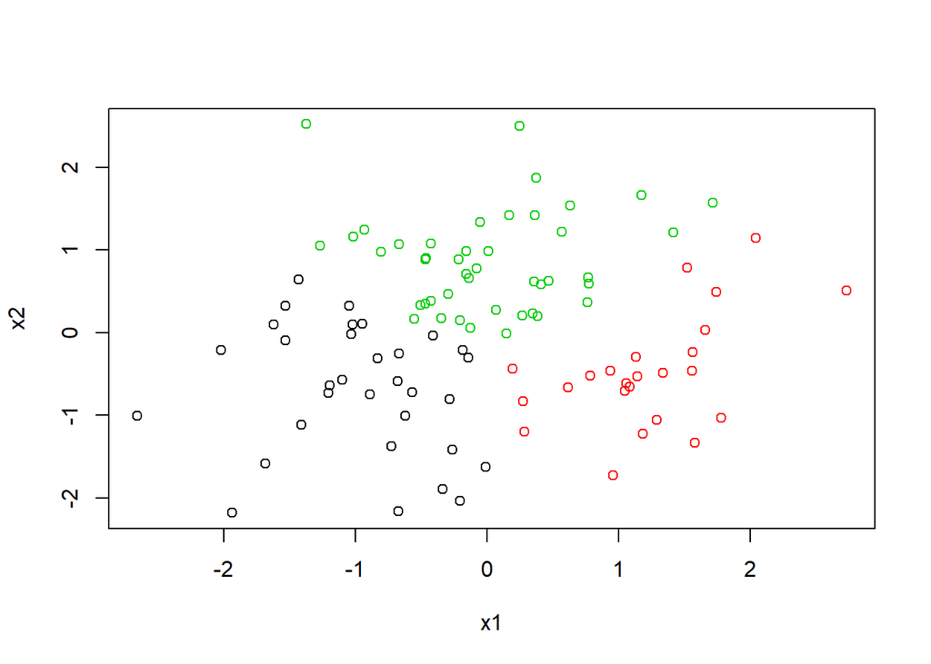

```r
plot(x1,x2,col=clust)
```

```r
c(cents,clust) %<-% Kmeans(data,3)
```

```
## [1] "Round: 0"
## [1] "Round: 1"
## [1] "Round: 2"
## [1] "Round: 3"
## [1] "Round: 4"
## [1] "Round: 5"
## [1] "Round: 6"
## [1] "Round: 7"
## [1] "Round: 8"
## [1] "Round: 9"
## [1] "Algorithm converged, total rounds:  10"
```

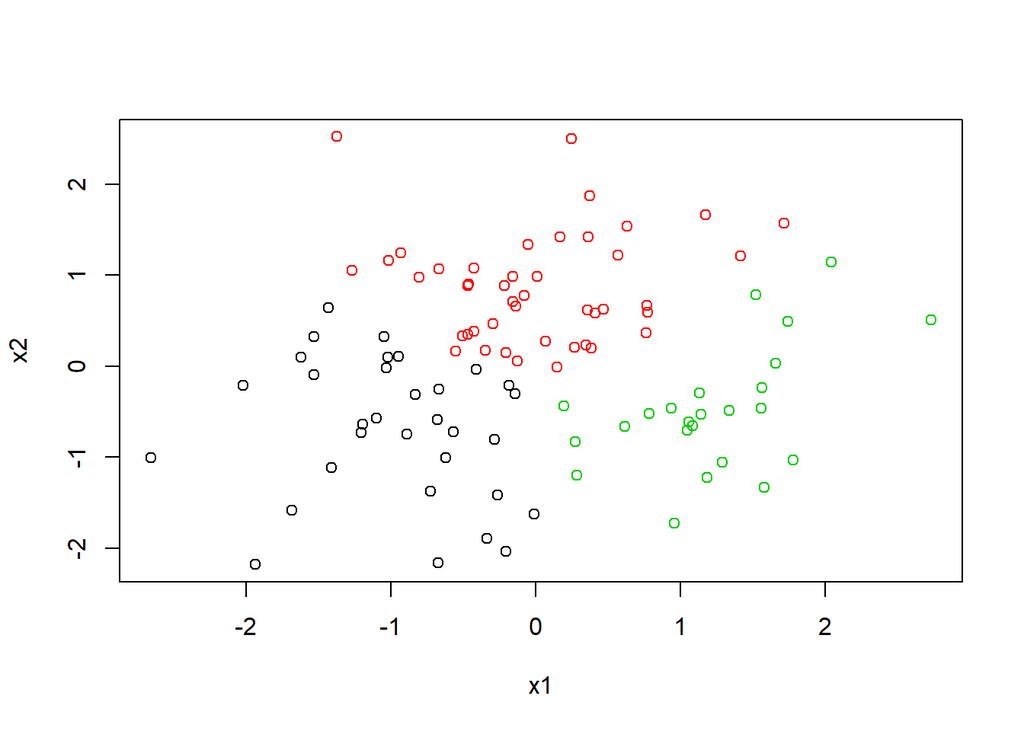

```r
plot(x1,x2,col=clust)
```

```r
c(cents,clust) %<-% Kmeans(data,3)
```

```
## [1] "Round: 0"
## [1] "Round: 1"
## [1] "Round: 2"
## [1] "Round: 3"
## [1] "Round: 4"
## [1] "Round: 5"
## [1] "Round: 6"
## [1] "Round: 7"
## [1] "Round: 8"
## [1] "Round: 9"
## [1] "Round: 10"
## [1] "Round: 11"
## [1] "Round: 12"
## [1] "Round: 13"
## [1] "Round: 14"
## [1] "Algorithm converged, total rounds:  15"
```

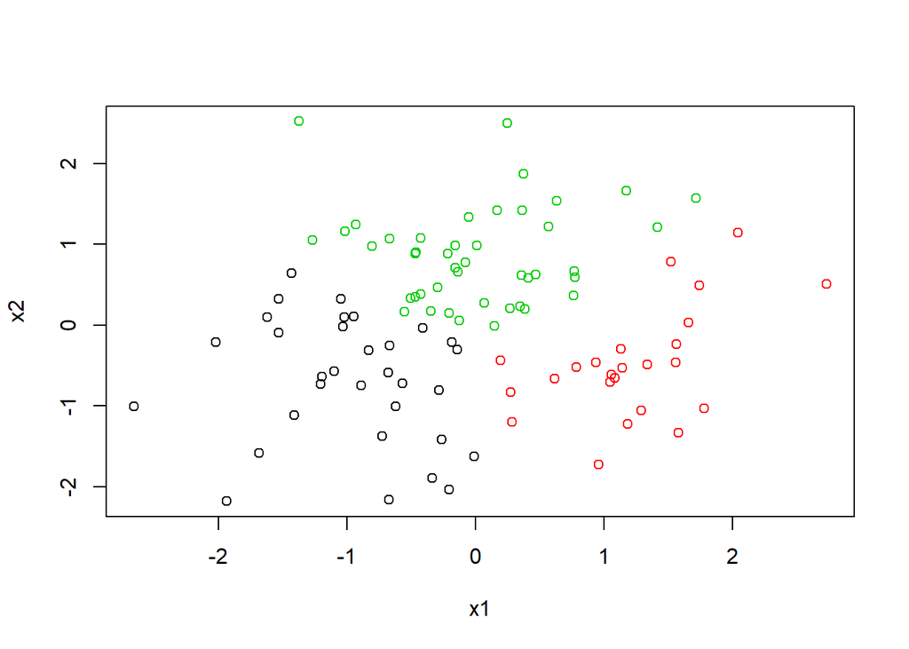

```r
plot(x1,x2,col=clust)
```

```r
c(cents,clust) %<-% Kmeans(data,3)
```

```
## [1] "Round: 0"
## [1] "Round: 1"
## [1] "Round: 2"
## [1] "Round: 3"
## [1] "Round: 4"
## [1] "Round: 5"
## [1] "Round: 6"
## [1] "Round: 7"
## [1] "Round: 8"
## [1] "Algorithm converged, total rounds:  9"
```

```r
plot(x1,x2,col=clust)
c(cents,clust) %<-% Kmeans(data,3)
```

[output not shown]

```
## [1] "Round: 0"
## [1] "Round: 1"
## [1] "Round: 2"
## [1] "Round: 3"
## [1] "Round: 4"
## [1] "Round: 5"
## [1] "Round: 6"
## [1] "Algorithm converged, total rounds:  7"
```

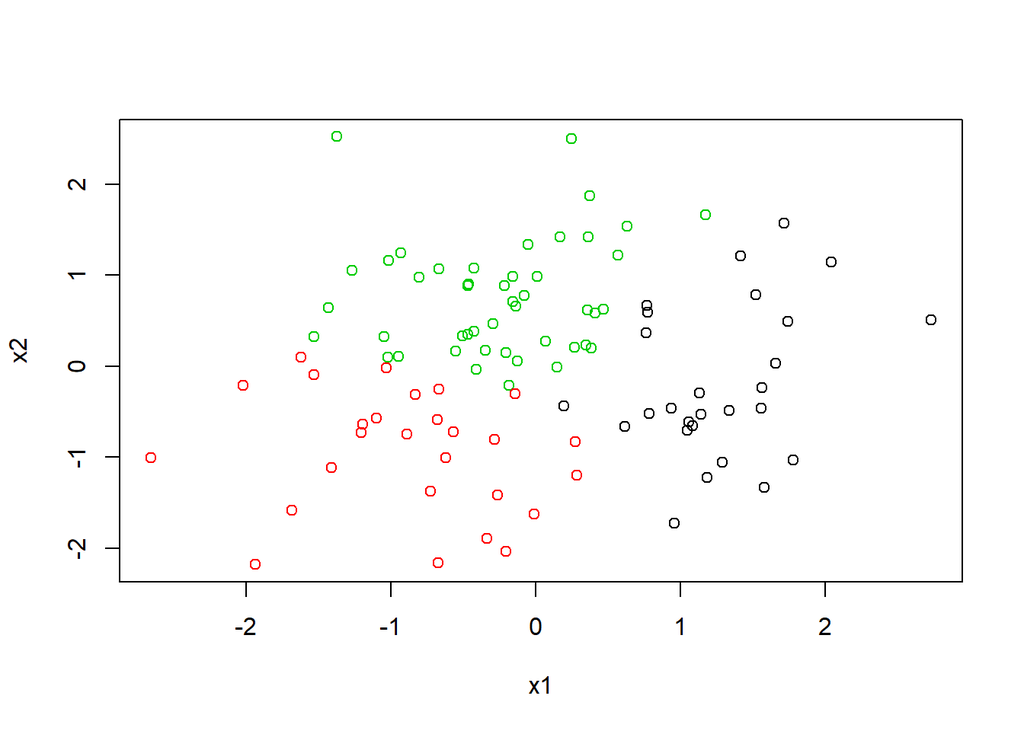

```r
plot(x1,x2,col=clust)
```

Conclusion: The clusters are surpricingly similar between different tries

#### Task 3b, MNIST data download

```r
# Load the MNIST digit recognition dataset into R
# http://yann.lecun.com/exdb/mnist/
# assume you have all 4 files and gunzip'd them
# creates train$n, train$x, train$y  and test$n, test$x, test$y
# e.g. train$x is a 60000 x 784 matrix, each row is one digit (28x28)
# call:  show_digit(train$x[5,])   to see a digit.
# brendan o'connor - gist.github.com/39760 - anyall.org

load_mnist <- function() {
  load_image_file <- function(filename) {
    ret = list()
    f = file(filename,'rb')
    readBin(f,'integer',n=1,size=4,endian='big')
    ret$n = readBin(f,'integer',n=1,size=4,endian='big')
    nrow = readBin(f,'integer',n=1,size=4,endian='big')
    ncol = readBin(f,'integer',n=1,size=4,endian='big')
    x = readBin(f,'integer',n=ret$n*nrow*ncol,size=1,signed=F)
    ret$x = matrix(x, ncol=nrow*ncol, byrow=T)
    close(f)
    ret
  }
  load_label_file <- function(filename) {
    f = file(filename,'rb')
    readBin(f,'integer',n=1,size=4,endian='big')
    n = readBin(f,'integer',n=1,size=4,endian='big')
    y = readBin(f,'integer',n=n,size=1,signed=F)
    close(f)
    y
  }
  train <<- load_image_file('./train-images-idx3-ubyte')
  test <<- load_image_file('./t10k-images.idx3-ubyte')

  train$y <<- load_label_file('./train-labels.idx1-ubyte')
  test$y <<- load_label_file('./t10k-labels.idx1-ubyte')
}


show_digit <- function(arr784, col=gray(12:1/12), ...) {
  image(matrix(arr784, nrow=28)[,28:1], col=col, ...)
}
```

```r
aload_image_file <- function(filename) {
    ret = list()
    f = file(filename,'rb')
    readBin(f,'integer',n=1,size=4,endian='big')
    ret$n = readBin(f,'integer',n=1,size=4,endian='big')
    nrow = readBin(f,'integer',n=1,size=4,endian='big')
    ncol = readBin(f,'integer',n=1,size=4,endian='big')
    x = readBin(f,'integer',n=ret$n*nrow*ncol,size=1,signed=F)
    ret$x = matrix(x, ncol=nrow*ncol, byrow=T)
    close(f)
    ret
  }
aload_label_file <- function(filename) {
    f = file(filename,'rb')
    readBin(f,'integer',n=1,size=4,endian='big')
    n = readBin(f,'integer',n=1,size=4,endian='big')
    y = readBin(f,'integer',n=n,size=1,signed=F)
    close(f)
    y
  }



#load_mnist()
#show_digit(train$x[5,])
```

```r
train <<- aload_image_file('./train-images.idx3-ubyte')
```

```r
train <<- aload_image_file('./train-images.idx3-ubyte')
test <<- aload_image_file('./t10k-images.idx3-ubyte')

ytrain <<- aload_label_file('./train-labels.idx1-ubyte')
ytest <<- aload_label_file('./t10k-labels.idx1-ubyte')
train$y = ytrain
test$y = ytest
```

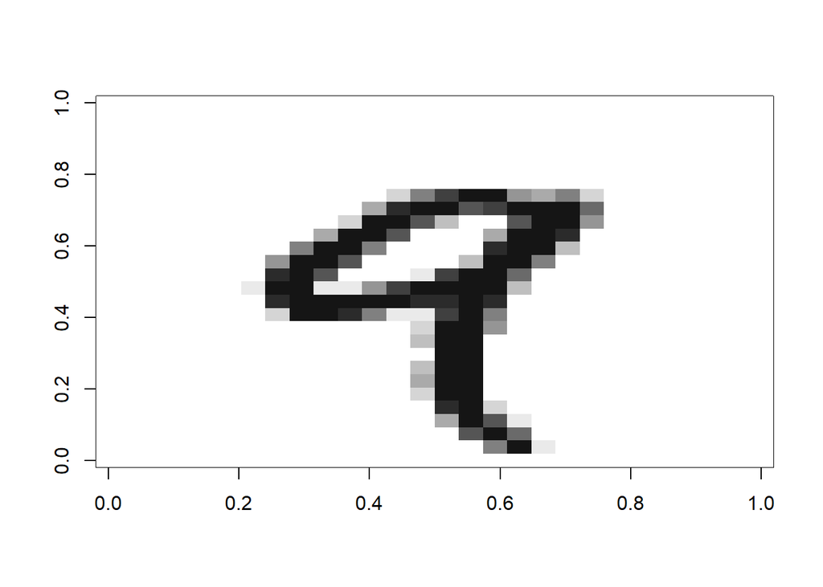

```r
show_digit(train$x[5,])
```

```r
str(train)
```

```
## List of 3
##  $ n: int 60000
##  $ x: int [1:60000, 1:784] 0 0 0 0 0 0 0 0 0 0 ...
##  $ y: int [1:60000] 5 0 4 1 9 2 1 3 1 4 ...
```

```r
str(test)
```

```
## List of 3
##  $ n: int 10000
##  $ x: int [1:10000, 1:784] 0 0 0 0 0 0 0 0 0 0 ...
##  $ y: int [1:10000] 7 2 1 0 4 1 4 9 5 9 ...
```

```r
newtrain = list()
newtrain$n <- 500
newtrain$x <- train$x[1:500,]
newtrain$y <- train$y[1:500]
```

```r
KmeansMod <- function(obs,K)
{
  #modified version, now initialize the clusters with first K observations

  #obs is a nxm matrix, with n observations and m features for each observation

  #Randomly assign a number, from 1 to K, to each of the observations.
  #These serve as initial cluster assignments for the observations.

  #clt is a list of clusters, clusters represented as lists
  #each list item is a list of indices of the original list (row indices) of observations
  nobs <- dim(obs)[1]
  nfeat <- dim(obs)[2]
  clt <- sample(x=1:K, size=nobs, replace=TRUE)
  #initialize data structure for centroids
  cent <- matrix(0,nrow = K, ncol = nfeat)
  count <- 0

  #Make first 10 observations the cluster means
  for (i in 1:K)
  {
    clt[i] = i
    cent[i,] <- obs[i,]
  }
  changed = TRUE

  while (changed && (count < 100))
  {
    changed = FALSE
    oldclt <- clt
    #(a) For each of the K clusters, compute the cluster centroid.
    #The kth cluster centroid is the vector of the p feature means
    #for the observations in the kth cluster.
    for (i in 1:K)
    {
      #centroid of this cluster
      rows <- which(clt==i)
      if (length(rows) > 1)
      {
        cent[i,] <- colMeans(obs[rows,], na.rm = FALSE, dims = 1)
      }
      else
      {
        cent[i,] <- obs[rows[1],]
      }
    }

    #(b) Assign each observation to the cluster whose centroid is
    #closest (where closest is defined using Euclidean distance).
    print(paste("Round:",count))

    for (i in 1:nobs)
    {
      clt[i] = closest(obs[i,],cent)
      if(clt[i] != oldclt[i])
      {
        changed <- TRUE
      }
    }

    count <- count + 1
    #print(oldclt)
    #print(clt)

  }
  print(paste("Algorithm converged, total rounds: ", count))
  return (list(cent,clt))
}
```

```r
c(cents1,clust1) %<-% KmeansMod(newtrain$x,10)
```

```
## [1] "Round: 0"
## [1] "Round: 1"
## [1] "Round: 2"
## [1] "Round: 3"
## [1] "Round: 4"
## [1] "Round: 5"
## [1] "Round: 6"
## [1] "Round: 7"
## [1] "Round: 8"
## [1] "Round: 9"
## [1] "Round: 10"
## [1] "Round: 11"
## [1] "Round: 12"
## [1] "Round: 13"
## [1] "Round: 14"
## [1] "Round: 15"
## [1] "Round: 16"
## [1] "Round: 17"
## [1] "Round: 18"
## [1] "Round: 19"
## [1] "Round: 20"
## [1] "Round: 21"
## [1] "Algorithm converged, total rounds:  22"
```

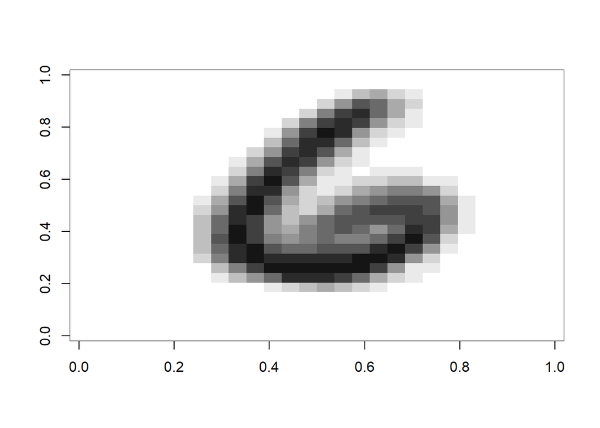

```r
show_digit(cents1[1,])
```

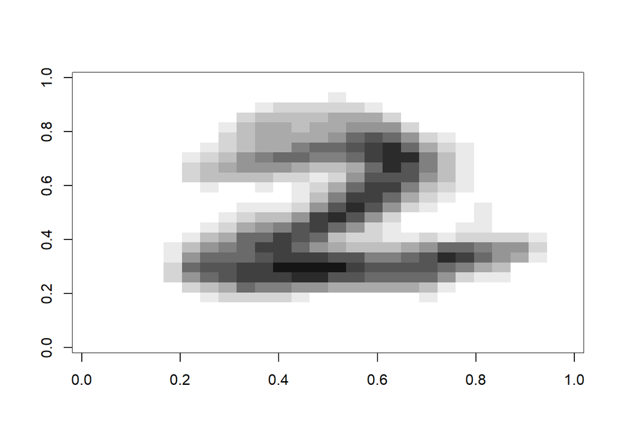

```r
show_digit(cents1[2,])
```

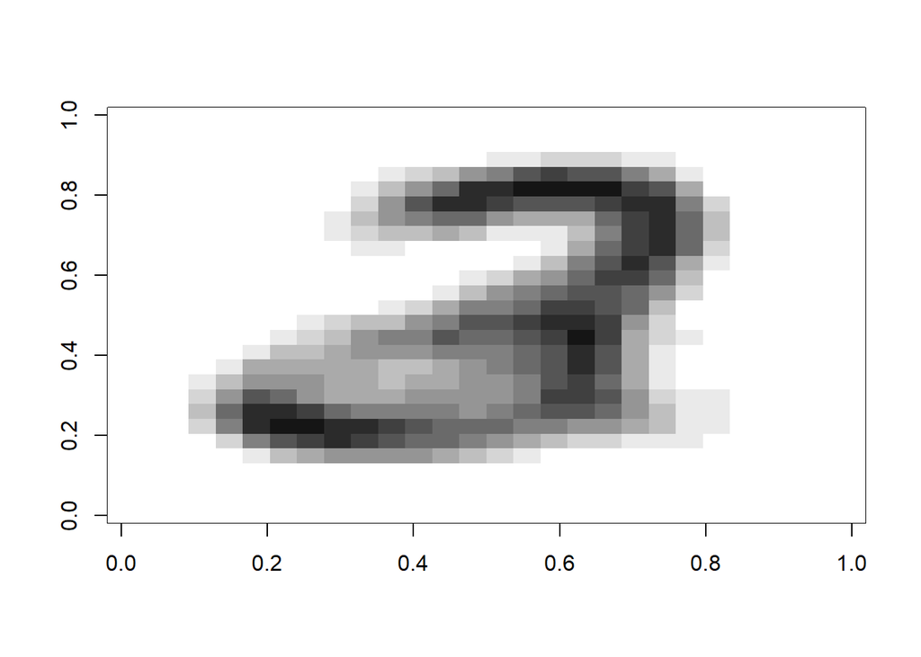

```r
show_digit(cents1[3,])
```

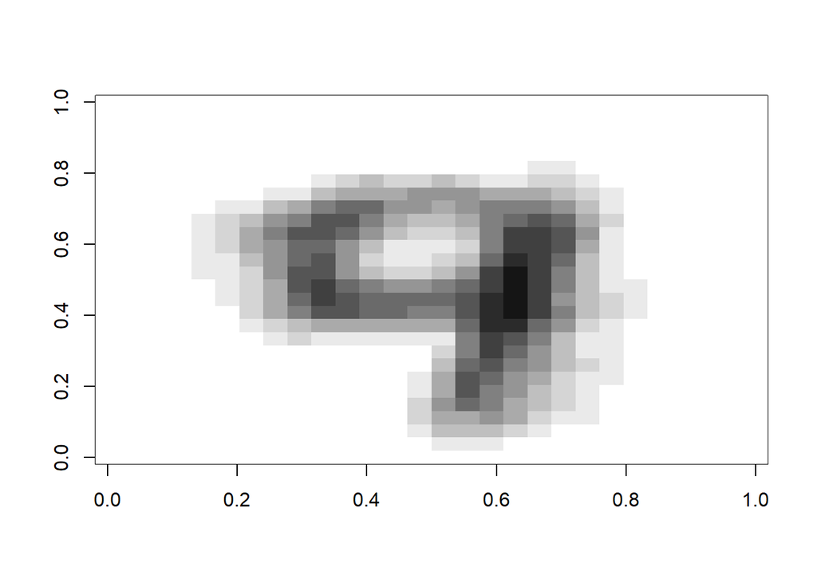

```r
show_digit(cents1[4,])
```

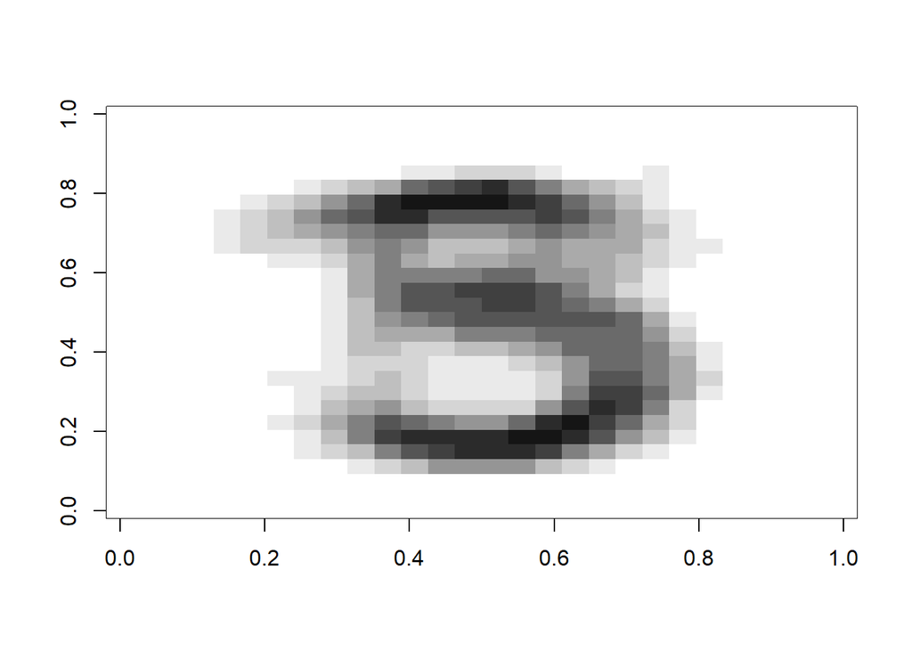

```r
show_digit(cents1[5,])
```

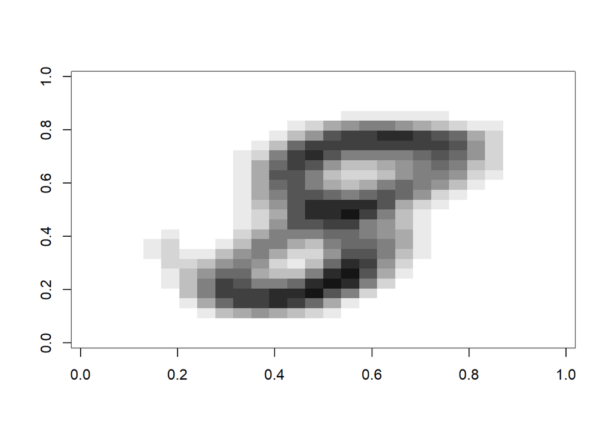

```r
show_digit(cents1[6,])
```

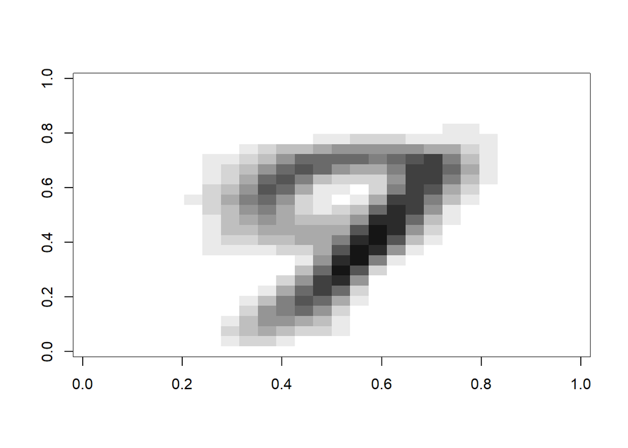

```r
show_digit(cents1[7,])
```

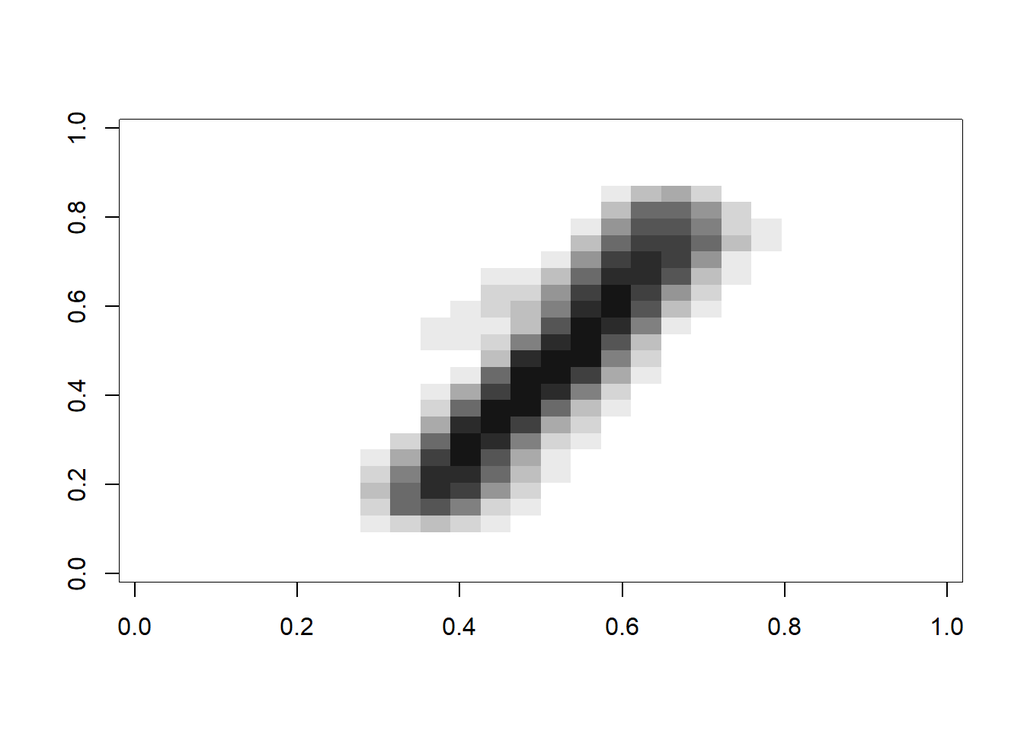

```r
show_digit(cents1[8,])
```

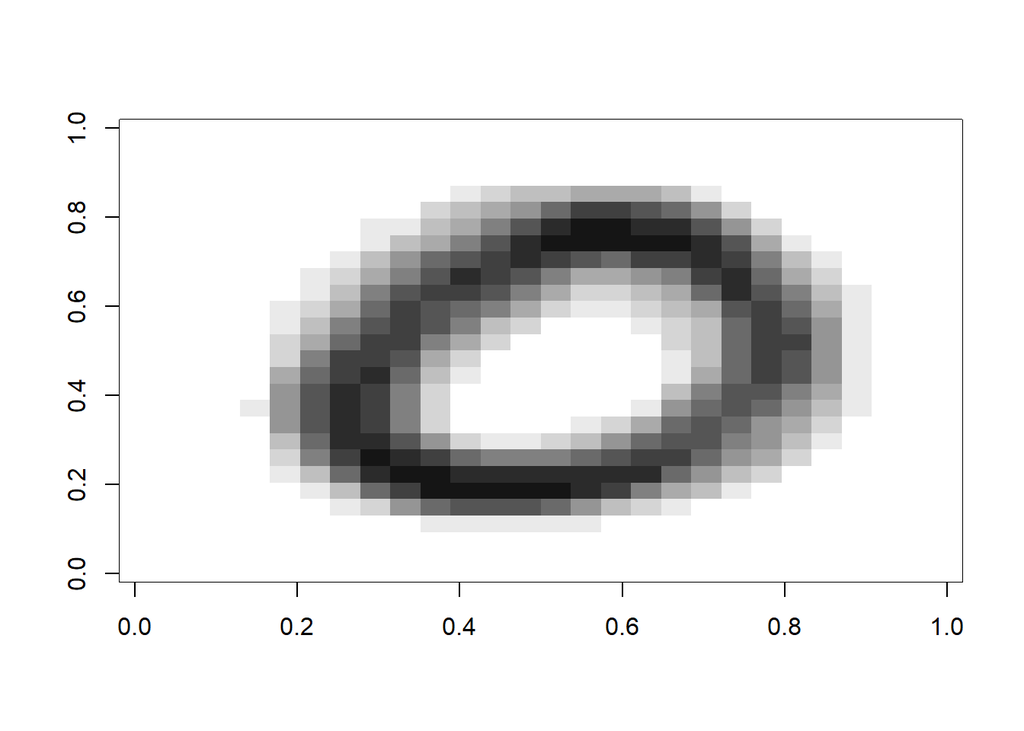

```r
show_digit(cents1[9,])
```

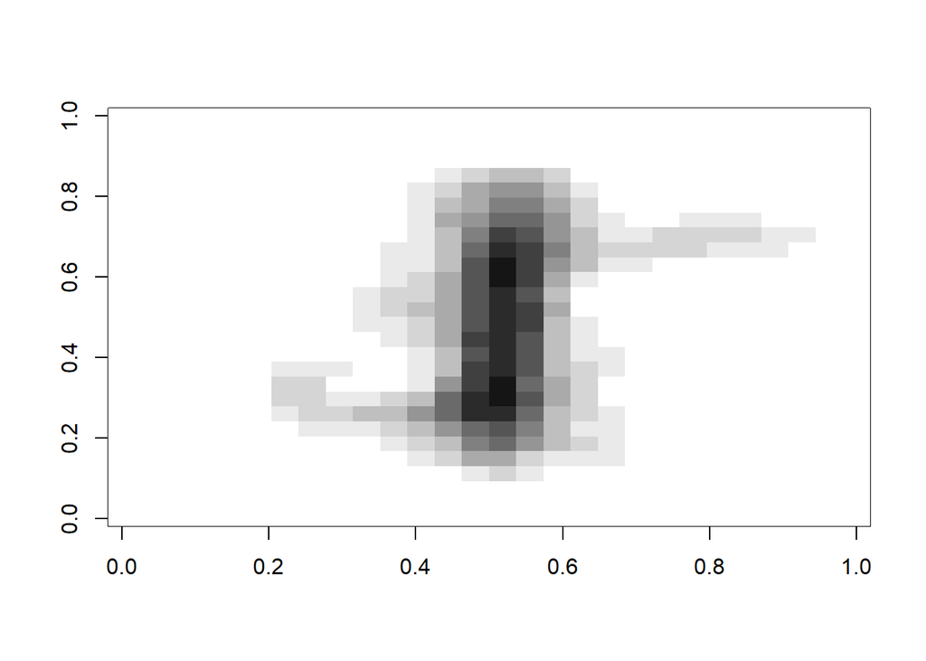

```r
show_digit(cents1[10,])
```

I can easily see many of the digits 0 - 9 represented here, 3, 9 and 8 seem to mix a bit, also 5 is bit fuzzy. Numbers 2, 3, 6, 7, 0 and 1 are somwht clear but there seems to be multiple 1 and also 9/4 mix

```r
#vals[clust]
vals <- c(9,0,6,5,4,1,3,2,7,8)
1-sum(vals[clust1]==train$y[1:500])/500
```

```
## [1] 0.994
```

```r
KmeansMod2 <- function(obs,K,labels)
{
  #modified version, now initialize the clusters with first instance if each K labels
  #Now it is more probable that each ith centroid will represent label i (not necessarily)

  #obs is a nxm matrix, with n observations and m features for each observation

  #Randomly assign a number, from 1 to K, to each of the observations.
  #These serve as initial cluster assignments for the observations.

  #clt is a list of clusters, clusters represented as lists
  #each list item is a list of indices of the original list (row indices) of observations
  nobs <- dim(obs)[1]
  nfeat <- dim(obs)[2]
  clt <- sample(x=1:K, size=nobs, replace=TRUE)
  #initialize data structure for centroids
  cent <- matrix(0,nrow = K, ncol = nfeat)
  count <- 0

  #initialize the clusters with first instance of each K labels
  for (i in 1:K)
  {
    j <- 1
    #search for first occurrence of this label i
    while(labels[j] != (i-1))
    {
      j = j + 1
    }
    #set jth observation into cluster i
    clt[j] = i
    #set observation j as the centroid of cluster with label i
    cent[i,] <- obs[j,]
  }
  changed = TRUE

  while (changed && (count < 100))
  {
    changed = FALSE
    oldclt <- clt
    #(a) For each of the K clusters, compute the cluster centroid.
    #The kth cluster centroid is the vector of the p feature means
    #for the observations in the kth cluster.
    for (i in 1:K)
    {
      #centroid of this cluster
      rows <- which(clt==i)
      if (length(rows) > 1)
      {
        cent[i,] <- colMeans(obs[rows,], na.rm = FALSE, dims = 1)
      }
      else
      {
        cent[i,] <- obs[rows[1],]
      }
    }

    #(b) Assign each observation to the cluster whose centroid is
    #closest (where closest is defined using Euclidean distance).
    print(paste("Round:",count))

    for (i in 1:nobs)
    {
      clt[i] = closest(obs[i,],cent)
      if(clt[i] != oldclt[i])
      {
        changed <- TRUE
      }
    }

    count <- count + 1
    #print(oldclt)
    #print(clt)

  }
  print(paste("Algorithm converged, total rounds: ", count))
  return (list(cent,clt))
}
```

```r
c(cents2,clust2) %<-% KmeansMod2(newtrain$x,10,newtrain$y)
```

```
## [1] "Round: 0"
## [1] "Round: 1"
## [1] "Round: 2"
## [1] "Round: 3"
## [1] "Round: 4"
## [1] "Round: 5"
## [1] "Round: 6"
## [1] "Round: 7"
## [1] "Round: 8"
## [1] "Round: 9"
## [1] "Algorithm converged, total rounds:  10"
```

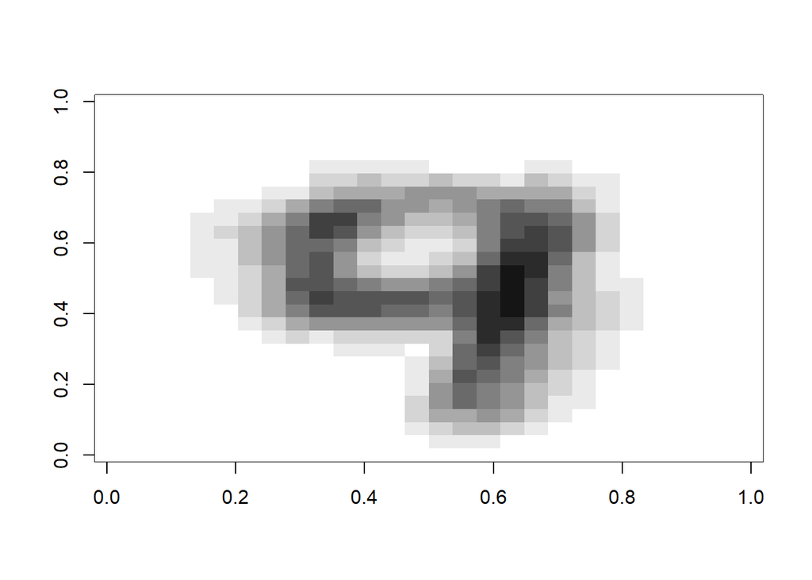

```r
show_digit(cents2[1,])
```

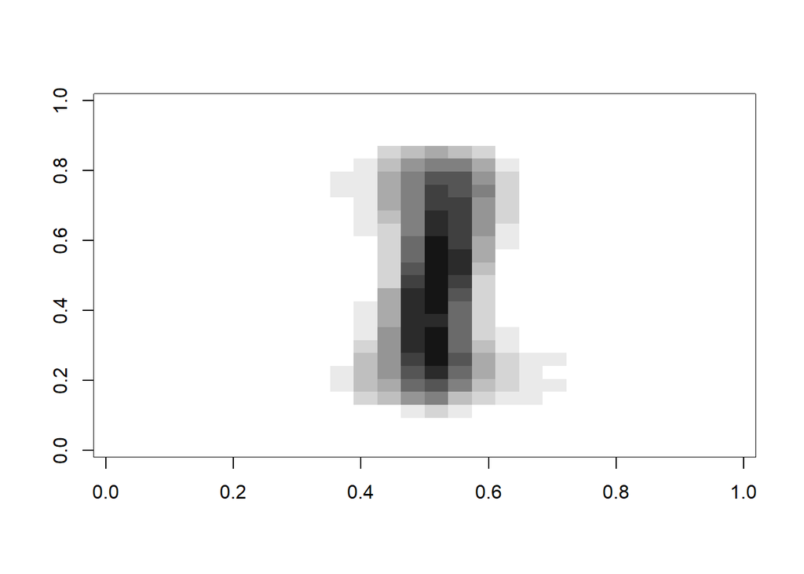

```r
show_digit(cents2[2,])
```

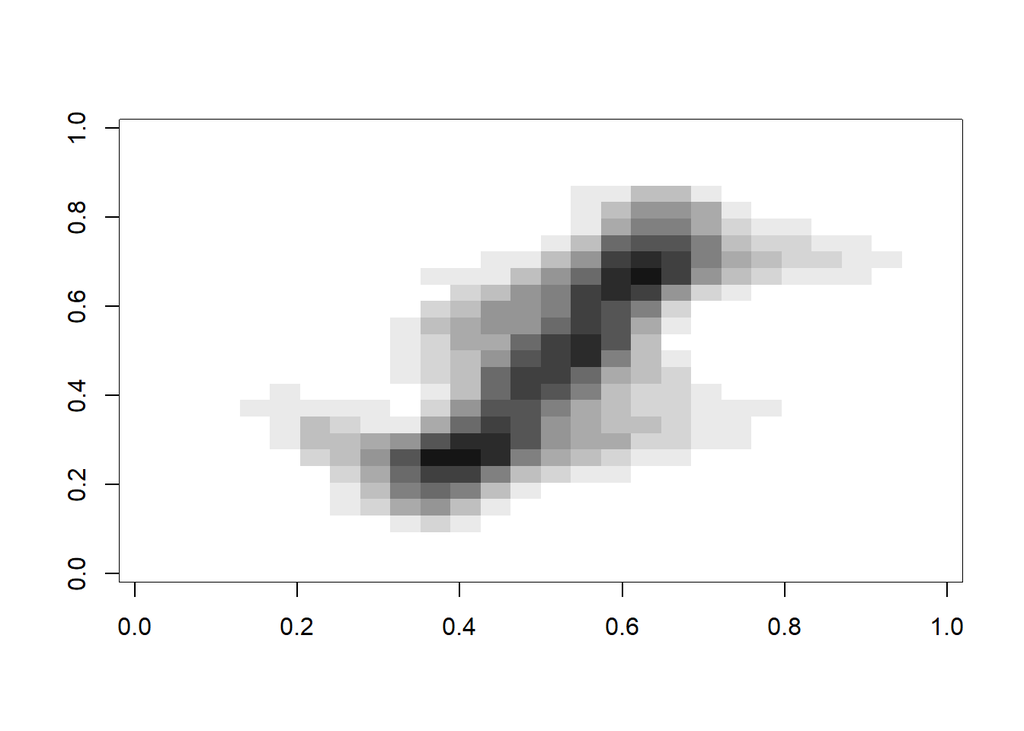

```r
show_digit(cents2[3,])
```

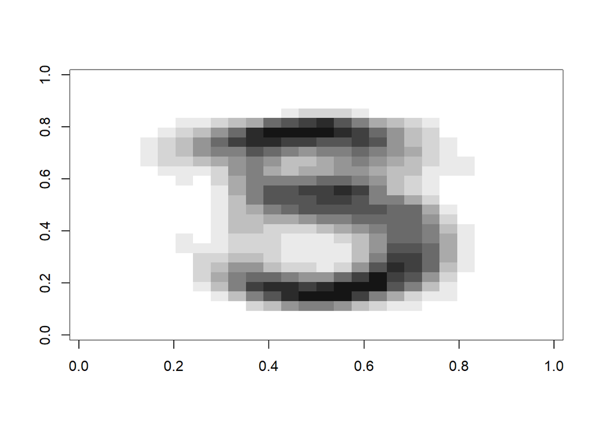

```r
show_digit(cents2[4,])
```

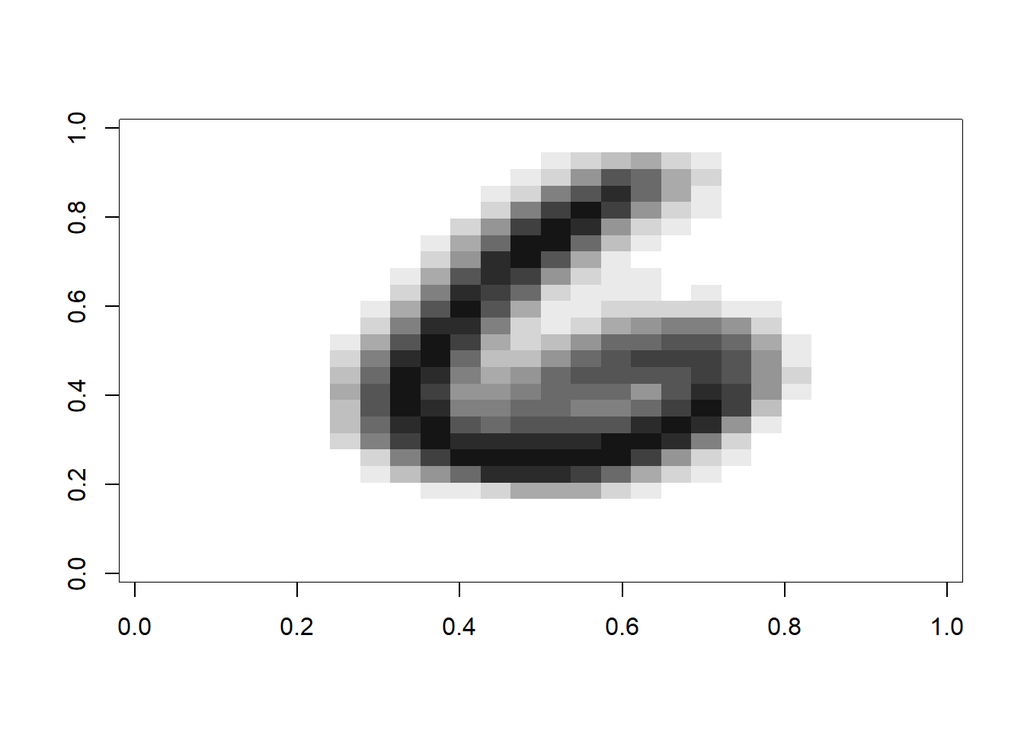

```r
show_digit(cents2[5,])
```

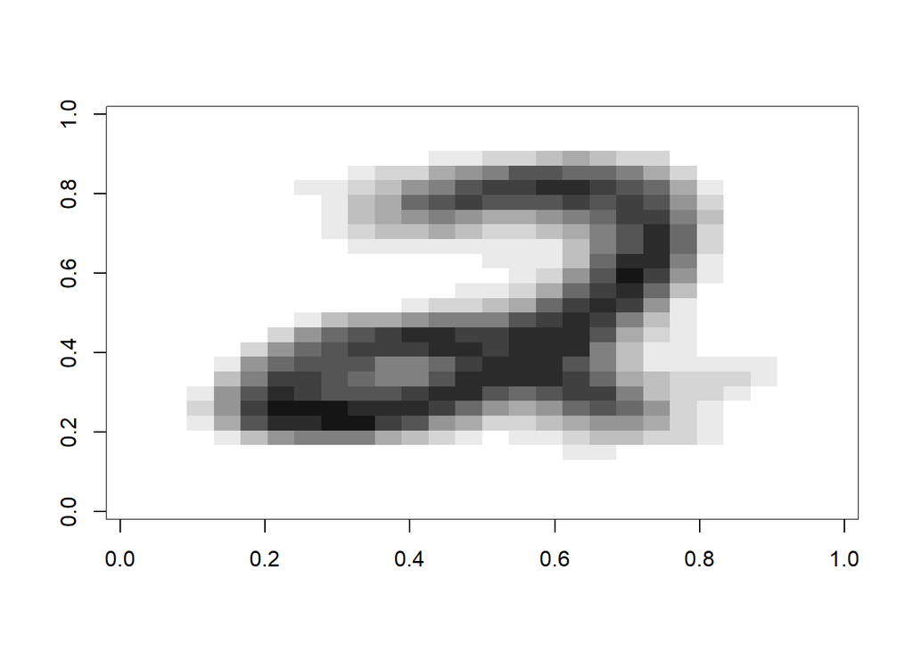

```r
show_digit(cents2[6,])
```

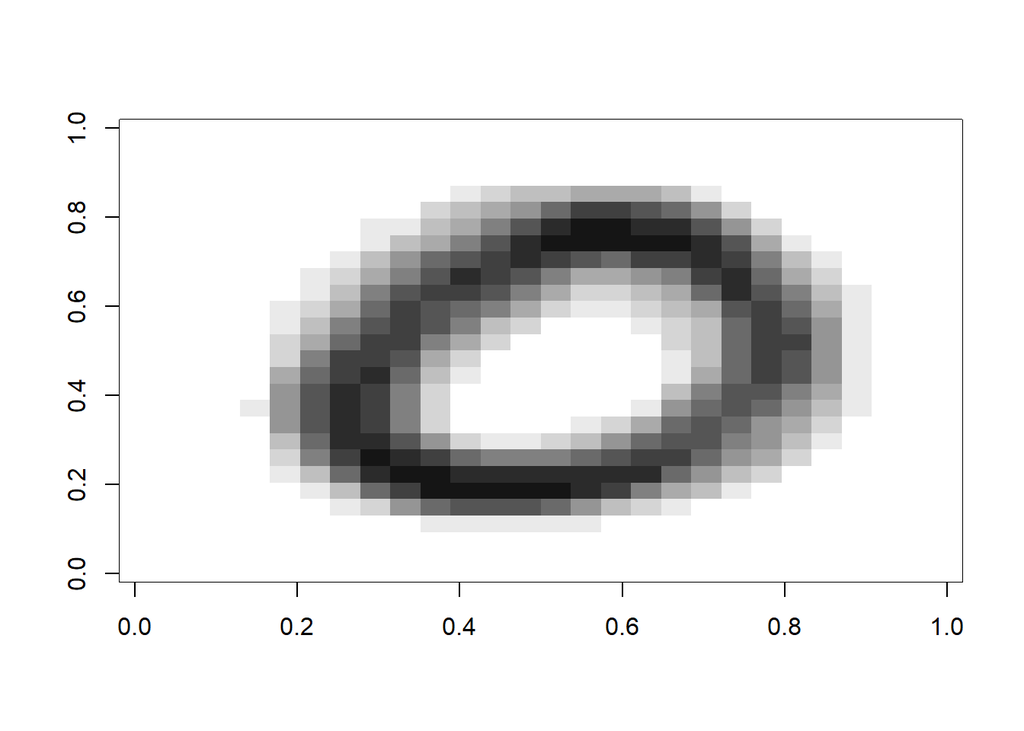

```r
show_digit(cents2[7,])
```

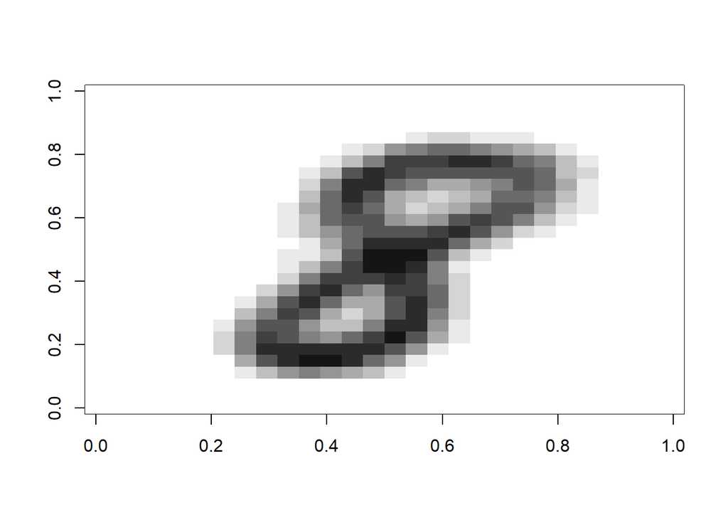

```r
show_digit(cents2[8,])
```

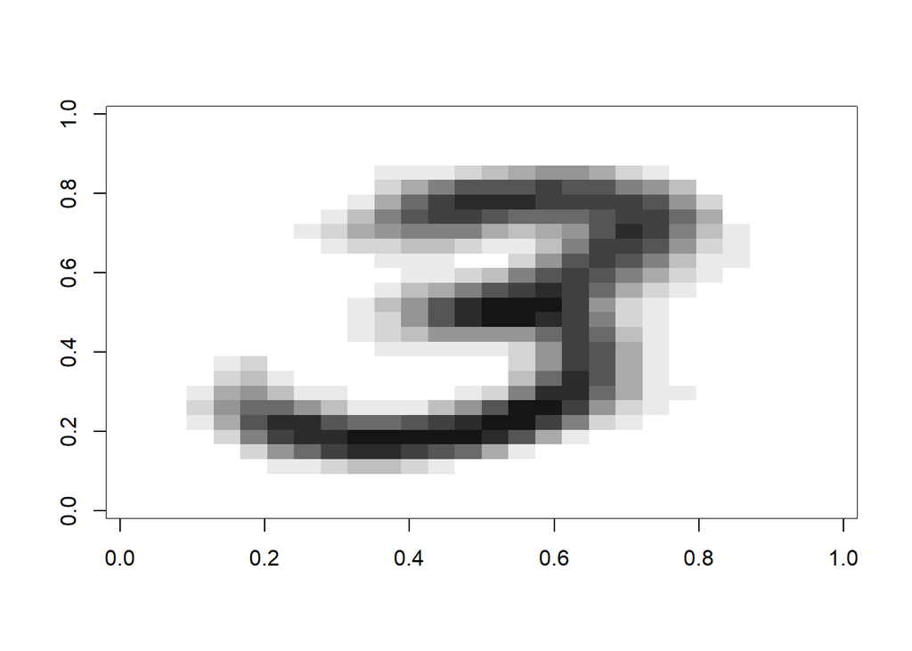

```r
show_digit(cents2[9,])
```

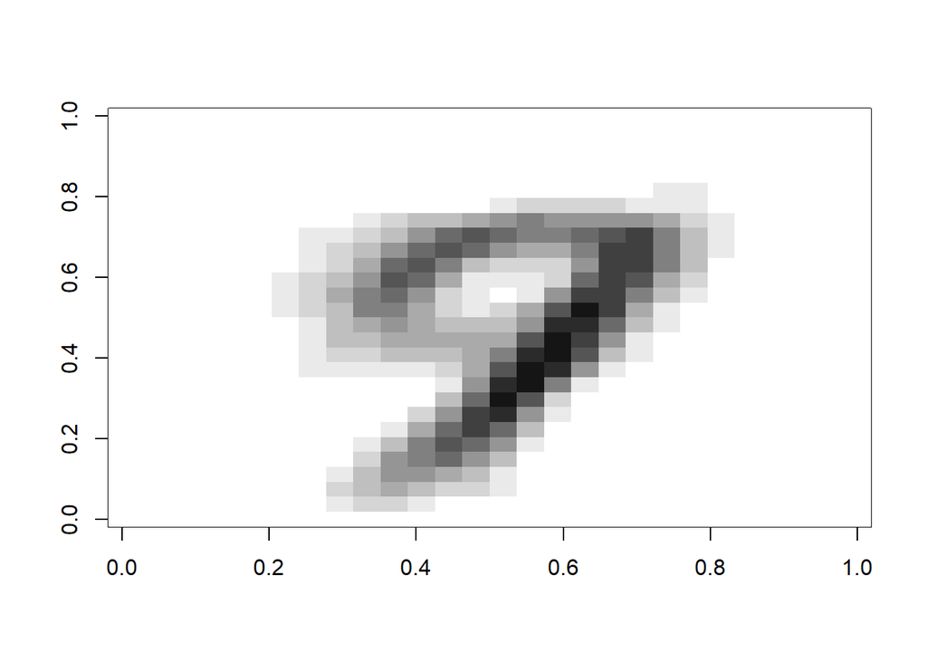

```r
show_digit(cents2[10,])
```

```r
vals2 <- c(9,8,6,1,2,0,7,3,4,5)
1-sum(vals2[clust2]==train$y[1:500])/500
```

```
## [1] 0.946
```

Well, now training error is more than 50%…